# Logstic Regression in R for Public Health

# Preparing the Data for Logistic Regression

Before we can dive into our analysis, we need to take a look at our variables using the skills and techniques discussed in the prior course. In addition to those methods, we also need to look at cross tabulations to see how the individual variables relate to our binary outcome variable. Cross tabulation can primarily be used for dichotomous variables (or those with fewer categories). For continuous variables, we can plot the continuous variables against the log odds of diabetes. We should also look at a distribution of these continuous variables with the number of patients of each age. An alternative is to create bins or groupings for plotting or cross tabulations. Often these will require trial and error to get them right. As we group variables into categories we also reduce the information we have available.

```r
data <- read.csv("diabetes.csv", header = TRUE, sep = ",")
dim(data) #check that the import worked properly (this will give the number of rows then the number of columns)
```

```
[1] 403  23
```

```r
colnames(data) #gives us the column names read into the data
```

```
 [1] "id"        "chol"      "stab.glu"  "hdl"       "ratio"     "glyhb"     "location"  "age"       "gender"    "height"    "weight"
[12] "frame"     "bp.1s"     "bp.1d"     "bp.2s"     "bp.2d"     "waist"     "hip"       "time.ppn"  "insurance" "fh"        "smoking"
[23] "dm"
```

Next, we can create variables in R (if we want) rather than refer directly to the column throughout our coding. We should also stipulate the type of variable we are creating.

```r
chol <- data["chol"] #continuous variable
gender <- as.factor(data[,"gender"]) #categorical variable
dm <- as.factor(data[,"dm"])
```

We’ll now create a table to see the breakdown of gender.

```r
gt <- table(gender) #stores the tabulation for further manipulation
addmargins(gt) #adds margins summing up the totals and printing the results
```

```
gender
female   male    Sum
   234    169    403
```

As the British teacher puts it, it’s incredibly annoying that it doesn’t give percentages. This can be done simply, though.

```r
round(prop.table(gt), digits = 3) #proportions rounded to the third decimal place
```

```
gender
female   male
 0.581  0.419
```

```r
round(100*prop.table(gt), digits = 1) #make it even easier with percentages rounded to first decimal place
```

```
gender
female   male
  58.1   41.9
```

Bear in mind, the table excludes missing values by default. We must add an argument to our prior syntax to include those missing items.

```r
dm2 <- factor(dm, exclude = NULL) #create a new factor from the old
table(dm2) #displays the counts including the missings (NAs)
```

```
dm2
  no  yes <NA>
 330   60   13
```

The summary function, as used in the prior class, is best suited for our continuous variables. NOw this one does include our NAs.

```r
summary (chol)
```

```
      chol
 Min.   : 78.0
 1st Qu.:179.0
 Median :204.0
 Mean   :207.8
 3rd Qu.:230.0
 Max.   :443.0
 NA's   :1
```

We’ll repeat this for the remaining variables we are interested in.

```r
height <- data[,"height"]
weight <- data[,"weight"]
summary(height)
```

```
   Min. 1st Qu.  Median    Mean 3rd Qu.    Max.    NA's
  52.00   63.00   66.00   66.02   69.00   76.00       5
```

```r
summary(weight)
```

```
   Min. 1st Qu.  Median    Mean 3rd Qu.    Max.    NA's
   99.0   151.0   172.5   177.6   200.0   325.0       1
```

For BMI calculations, we’ll convert to SI units.

```r
height.si <- height*0.0254
weight.si <- weight*0.453592
bmi <- weight.si/height.si^2
summary(bmi)
```

[output not shown]

Often we need to categorize our data to make it useable for our analyses (even if it loses information). In this case, we are going to categorize our BMI data to meaningful categories.

```r
bmi_cat <- ifelse(bmi < 18.5, "underweight",
                  ifelse(bmi >= 18.5 & bmi <= 25, "normal",
                         ifelse(bmi > 25 & bmi <= 30, "overweight",
                                ifelse(bmi > 30, "obese", NA))))
table(bmi_cat, exclude = NULL) #verify the categorization worked appropriately and include NAs
```

```
bmi_cat
     normal       obese  overweight underweight        <NA>
        113         152         123           9           6
```

Let’s make our first cross tabulation examining the relationship between BMI category and diabetes.

```r
dm_by_bmi_cat <- table(bmi_cat, dm2, exclude = NULL) #frequencies of diabetes by BMI category
dm_by_bmi_cat #print results
```

```
             dm2
bmi_cat        no yes <NA>
  normal      100   9    4
  obese       118  29    5
  overweight   99  20    4
  underweight   9   0    0
  <NA>          4   2    0
```

```r
round(100*prop.table(dm_by_bmi_cat, margin = 1), digits = 1) #with row percentages
```

```
             dm2
bmi_cat          no   yes  <NA>
  normal       88.5   8.0   3.5
  obese        77.6  19.1   3.3
  overweight   80.5  16.3   3.3
  underweight 100.0   0.0   0.0
  <NA>         66.7  33.3   0.0
```

## Quiz for Cross Tabulation

1. Now it’s your turn to have a go. It’s always useful to describe the age-sex distribution of your set of patients. The first task is to make age groups from age, allowing for any missing values. To make it manageable, go for just four age groups: under 45, 45-64, 65-74 and 75 or over. Then tabulate age group by itself, followed by a cross-tabulation with gender. Finally, add the overall percentages to this cross-tab. What is the number of females under age 45?

```r
age <- data["age"]
age_cat <- ifelse(age < 45, "Under 45",
                  ifelse(age >= 45 & age <= 64, "45-64",
                         ifelse(age >= 65 & age <= 74, "65-74",
                                ifelse(age >= 75, "75 and Over", NA))))
age_by_gender <- table(age_cat, gender, exclude = NULL)
```

2. Now, enter the percentage of all patients who are male and aged 65-74 rounded to nearest whole percentage.

```r
round(100*prop.table(age_by_gender), digits = 1)
```

```
             gender
age_cat       female male
  45-64         18.6 15.9
  65-74          5.2  5.0
  75 and Over    3.0  2.7
  Under 45      31.3 18.4
```

3. Were there any missing values for age and/or gender?

```r
table(age, exclude = NULL)
```

```
age
19 20 21 22 23 24 25 26 27 28 29 30 31 32 33 34 35 36 37 38 39 40 41 42 43 44 45 46 47 48 49 50 51 52 53 54 55 56 57 58 59 60 61 62 63 64 65 66
 2 10  6  5  7  1  4  6  9  9  7  9 10  4  6  7  5 13 11 11  2 16 13  7 13  7  9  4  7  7  5 10  8  8  7  6  7  4  4  7  8 10  7  5 11  5  6  7
67 68 69 70 71 72 73 74 75 76 78 79 80 81 82 83 84 89 91 92
 4  6  1  4  4  4  2  3  2  5  4  2  2  1  2  1  1  1  1  1
```

```r
table(gender, exclude = NULL)
```

```
gender
female   male
   234    169
```

# Simple Logistic Regression in R

We’re going to start with the simplest model for diabetes (the null/empty model that is rarely useful) that has no predictors.

```r
glm(dm ~ 1, family = binomial (link = logit))
```

```
Call:  glm(formula = dm ~ 1, family = binomial(link = logit))

Coefficients:
(Intercept)
     -1.705

Degrees of Freedom: 389 Total (i.e. Null);  389 Residual
  (13 observations deleted due to missingness)
Null Deviance:      334.9
Residual Deviance: 334.9    AIC: 336.9
```

To obtain the full output, we need to utilize the summary command.

```r
m <- glm(dm ~ 1, family = binomial (link = logit))
summary(m)
```

```
Call:
glm(formula = dm ~ 1, family = binomial(link = logit))

Deviance Residuals:
   Min      1Q  Median      3Q     Max
-0.578  -0.578  -0.578  -0.578   1.935

Coefficients:
            Estimate Std. Error z value Pr(>|z|)
(Intercept)  -1.7047     0.1403  -12.15   <2e-16 ***
---
Signif. codes:  0 ‘***’ 0.001 ‘**’ 0.01 ‘*’ 0.05 ‘.’ 0.1 ‘ ’ 1

(Dispersion parameter for binomial family taken to be 1)

    Null deviance: 334.87  on 389  degrees of freedom
Residual deviance: 334.87  on 389  degrees of freedom
  (13 observations deleted due to missingness)
AIC: 336.87

Number of Fisher Scoring iterations: 3
```

A much more useful model is one that includes at least one or more predictors. First, let’s take a look at the relationship between gender and diabetes.

```r
m <- glm(dm ~ gender, family = binomial (link = logit))
summary(m)
```

```
Call:
glm(formula = dm ~ gender, family = binomial(link = logit))

Deviance Residuals:
    Min       1Q   Median       3Q      Max
-0.5915  -0.5915  -0.5683  -0.5683   1.9509

Coefficients:
            Estimate Std. Error z value Pr(>|z|)
(Intercept) -1.74150    0.18592  -9.367   <2e-16 ***
gendermale   0.08694    0.28352   0.307    0.759
---
Signif. codes:  0 ‘***’ 0.001 ‘**’ 0.01 ‘*’ 0.05 ‘.’ 0.1 ‘ ’ 1

(Dispersion parameter for binomial family taken to be 1)

    Null deviance: 334.87  on 389  degrees of freedom
Residual deviance: 334.78  on 388  degrees of freedom
  (13 observations deleted due to missingness)
AIC: 338.78

Number of Fisher Scoring iterations: 4
```

We can do the same thing with a continuous predictor, such as age.

```r
m <- glm(dm ~ age, family = binomial (link = logit))
summary(m)
```

```
Call:
glm(formula = dm ~ age, family = binomial(link = logit))

Deviance Residuals:
    Min       1Q   Median       3Q      Max
-1.3612  -0.5963  -0.4199  -0.3056   2.4848

Coefficients:
             Estimate Std. Error z value Pr(>|z|)
(Intercept) -4.404530   0.542828  -8.114 4.90e-16 ***
age          0.052465   0.009388   5.589 2.29e-08 ***
---
Signif. codes:  0 ‘***’ 0.001 ‘**’ 0.01 ‘*’ 0.05 ‘.’ 0.1 ‘ ’ 1

(Dispersion parameter for binomial family taken to be 1)

    Null deviance: 334.87  on 389  degrees of freedom
Residual deviance: 299.41  on 388  degrees of freedom
  (13 observations deleted due to missingness)
AIC: 303.41

Number of Fisher Scoring iterations: 5
```

The previous model assumes a linear relationship between age and the log odds of having diabetes. Let’s check that assumption.

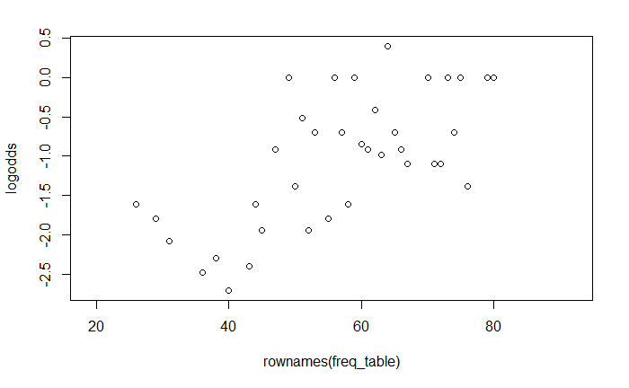

```r
dm_by_age <- table (age, dm) #create a cross tabulation of age and diabetes status
freq_table <- prop.table(dm_by_age, margin = 1) #output the frequencies of diabetes status by age
odds <- freq_table[,"yes"]/freq_table[,"no"] #calculate the odds of having diabetes
logodds <- log(odds) #calculate the log odds
plot(rownames(freq_table), logodds) #plot the ages found in the sample against the log odds of having diabetes
```

While gender in this example is well labeled, it’s a good idea to check how R has entered gender into the model using the *contrasts()* command.

```r
contrasts(gender)
```

```
       male
female    0
male      1
```

Suppose we want to compare the reverse (where male is the reference value). Let’s check the order with the *levels()* commands.

```r
levels(gender)
```

```
[1] "female" "male"
```

We can then use the *relevel()* function to change the reference value. Then, let’s re-run the regression.

```r
gender <- relevel(gender, ref = "male")
levels(gender)
```

```
[1] "male"   "female"
```

```r
m <- glm(dm ~ gender, family = binomial (link = logit))
summary(m)
```

```
Call:
glm(formula = dm ~ gender, family = binomial(link = logit))

Deviance Residuals:
    Min       1Q   Median       3Q      Max
-0.5915  -0.5915  -0.5683  -0.5683   1.9509

Coefficients:
             Estimate Std. Error z value Pr(>|z|)
(Intercept)  -1.65456    0.21404  -7.730 1.08e-14 ***
genderfemale -0.08694    0.28352  -0.307    0.759
---
Signif. codes:  0 ‘***’ 0.001 ‘**’ 0.01 ‘*’ 0.05 ‘.’ 0.1 ‘ ’ 1

(Dispersion parameter for binomial family taken to be 1)

    Null deviance: 334.87  on 389  degrees of freedom
Residual deviance: 334.78  on 388  degrees of freedom
  (13 observations deleted due to missingness)
AIC: 338.78

Number of Fisher Scoring iterations: 4
```

As we would expect, log(A/B) = -log(B/A). It is important to note that the glm command produces an R object with various elements, identified using the dollar symbol, that can be manipulated and exported. This is why we store glm as an object.

```r
m$coefficients #see the model's coefficients
```

```
 (Intercept) genderfemale
 -1.65455835  -0.08693929
```

```r
exp(m$coefficients) #produce the odds ratios for all coefficients
```

```
 (Intercept) genderfemale
   0.1911765    0.9167328
```

## Quiz for Interpreting Simple Logistic Regression

1. Use the course data set and the R commands you’ve learned so far on this course to answer the following. Of those with a recorded diabetes status, what percentage of people from Buckingham have diabetes?

```r
round(100*prop.table(dm_by_location, margin = 2), digits = 1)
```

```
     location
dm    Buckingham Louisa
  no        83.7   85.5
  yes       16.3   14.5
```

2. Now fit a logistic regression with “location” as the predictor variable. What are the log odds of having diabetes being from Louisa compared with Buckingham? Give the answer (the log odds ratio) to two decimal places.

```r
m <- glm(dm ~ location, family = binomial (link = logit))
summary(m)
```

```
Call:
glm(formula = dm ~ location, family = binomial(link = logit))

Deviance Residuals:
    Min       1Q   Median       3Q      Max
-0.5969  -0.5969  -0.5597  -0.5597   1.9652

Coefficients:
               Estimate Std. Error z value Pr(>|z|)
(Intercept)     -1.6349     0.1963  -8.327   <2e-16 ***
locationLouisa  -0.1395     0.2809  -0.497     0.62
---
Signif. codes:  0 ‘***’ 0.001 ‘**’ 0.01 ‘*’ 0.05 ‘.’ 0.1 ‘ ’ 1

(Dispersion parameter for binomial family taken to be 1)

    Null deviance: 334.87  on 389  degrees of freedom
Residual deviance: 334.63  on 388  degrees of freedom
  (13 observations deleted due to missingness)
AIC: 338.63

Number of Fisher Scoring iterations: 4
```

3. Using the regression results from the previous item, is location a statistically significant predictor of having diabetes in our sample?
4. Using the data from the previous item, what are the odds of having diabetes being from Louisa compared with Buckingham? (to two decimal places)

```r
exp(m$coefficients)
```

```
   (Intercept) locationLouisa
     0.1949686      0.8698359
```

# Multiple Logistic Regression in R

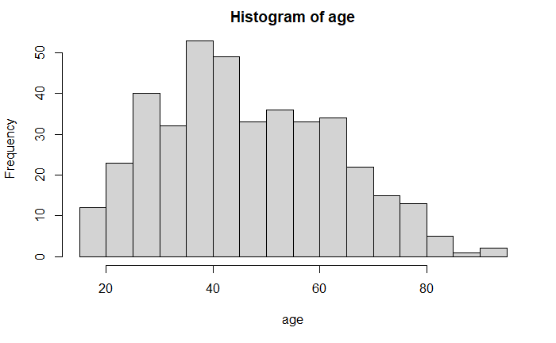

```r
hist(age, breaks = 12) #you can include a breaks argument to specify the number of bins
```

Some people prefer fancier plots than histograms since they are affected by the choice of bins. One could utilize a kernel density plot (or just density plot):

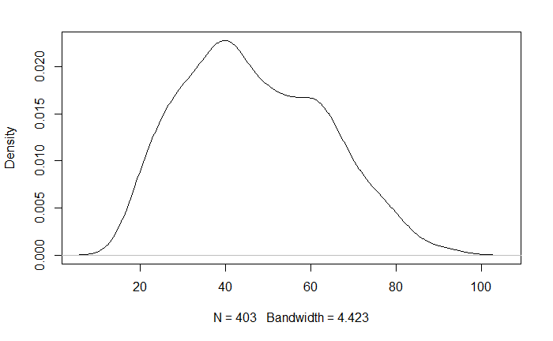

```r
d <- density(age)
plot(d, main = "") #gives warnings but the “main” argument suppresses the ugly default title
```

The above chart uses a kernel smoothing method using the weighted average of neighboring data. The bandwidth tells you the amount of data used during the averaging. One thing to bear in mind is that this method gives values that do not actually exist in the data based on the modelling.

## Practice in R: Describing Variables

For this activity, I’d like you to consider not just age and gender but also BMI, HDL and cholesterol. Have a go at summarizing each of them separately – numerically and with plots.

The next step is to see how each variable relates to the outcome variable, i.e. having diabetes, just as we did with age earlier. For gender, this is just a cross-tab, but for BMI, HDL and cholesterol it’s not quite so straightforward. Have a go at that too.

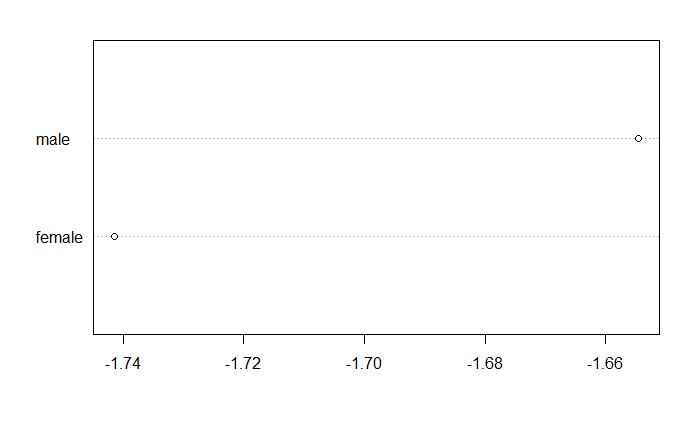

The chart is not very useful. Another chart option will draw lines instead of dots, but also isn’t very useful in this case.

```r
plot(as.factor(names(logodds_gender)), logodds_gender)
```

[output not shown]

Let’s take a look now at the relationship between age and diabetes:

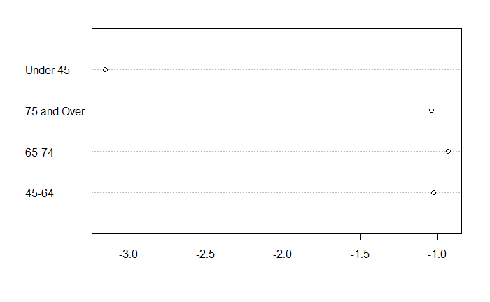

Cholesterol example: Before looking at relationships between variables, we should look at our predictors first. Start with a distribution plot and running frequency tabulations. Let’s take a look first at cholesterol.

```r
summary(chol)
```

```
      chol
 Min.   : 78.0
 1st Qu.:179.0
 Median :204.0
 Mean   :207.8
 3rd Qu.:230.0
 Max.   :443.0
 NA's   :1
```

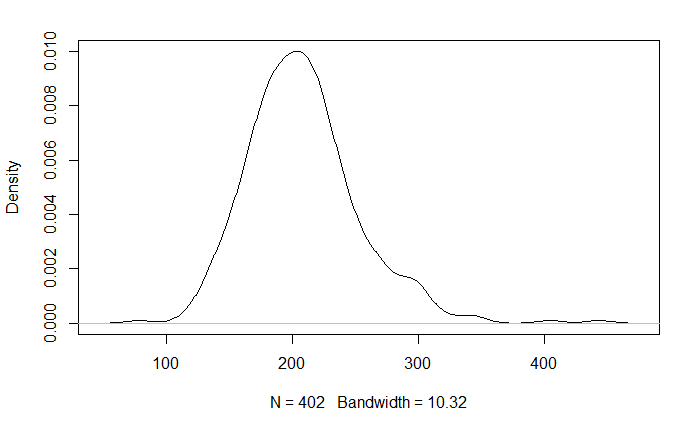

```r
chol.no.na <- chol[is.na(chol)==0]
d <- density(chol.no.na)
plot(d, main = "")
```

## How to Run Multiple Logistic Regression in R

Instructions: Now run a multiple regression model so you can see what the output looks like. I’d like you to fit a model with age, gender and BMI as predictors. The previous exploratory analyses will have told you how to include them. After running the model, there’ll be a chance to debate the results with your peers in a Discussion Prompt.

```r
m <- glm(dm ~ age + gender + bmi, family=binomial (link=logit))
summary(m)
```

[output not shown]

```r
exp(confint(m))
```

```
                   2.5 %      97.5 %
(Intercept) 0.0001226733 0.006986056
age         1.0373532463 1.078493131
gendermale  0.6762611041 2.409679250
bmi         1.0287121260 1.127738696
```

## Quiz: Running A New Logistic Regression Model

1. Using the same data set as before, now try another model with these predictor variables: age, cholesterol and insurance type. The data set can be downloaded here.

Enter the odds ratios for each predictor in the boxes below to two decimal places. Check whether each one is considered statistically significant at the conventional 5% threshold.

```r
chol <- data[,"chol"]
insurance <- as.factor(data[,"insurance"])
m <- glm(dm ~ age + chol + insurance, family = binomial(link = logit))
summary(m)
```

```
Call:
glm(formula = dm ~ age + chol + insurance, family = binomial(link = logit))

Deviance Residuals:
    Min       1Q   Median       3Q      Max
-1.5714  -0.5945  -0.3992  -0.2619   2.4399

Coefficients:
             Estimate Std. Error z value Pr(>|z|)
(Intercept) -5.794252   0.874555  -6.625 3.46e-11 ***
age          0.049753   0.009770   5.092 3.54e-07 ***
chol         0.008402   0.003153   2.665   0.0077 **
insurance1  -0.271955   0.359445  -0.757   0.4493
insurance2  -0.589803   0.377434  -1.563   0.1181
---
Signif. codes:  0 ‘***’ 0.001 ‘**’ 0.01 ‘*’ 0.05 ‘.’ 0.1 ‘ ’ 1

(Dispersion parameter for binomial family taken to be 1)

    Null deviance: 334.54  on 388  degrees of freedom
Residual deviance: 289.28  on 384  degrees of freedom
  (14 observations deleted due to missingness)
AIC: 299.28

Number of Fisher Scoring iterations: 5
```

```r
exp(m$coefficients)
```

```
(Intercept)         age        chol  insurance1  insurance2
0.003045009 1.051011544 1.008437550 0.761888740 0.554436387
```

```r
exp(confint(m))
```

```
                   2.5 %    97.5 %
(Intercept) 0.0005079001 0.0159153
age         1.0315787639 1.0720130
chol        1.0022390155 1.0148096
insurance1  0.3749368651 1.5449046
insurance2  0.2611364934 1.1558103
```

# Assessing Model Fit

Demonstration of null deviance and residual deviance:

```r
# design your logistic regression
full_model <- glm(dm ~ age + chol + insurance, family = binomial(link = logit))

# analyse table of deviance
anova(full_model, test = "Chisq")
```

```
Analysis of Deviance Table

Model: binomial, link: logit

Response: dm

Terms added sequentially (first to last)

          Df Deviance Resid. Df Resid. Dev  Pr(>Chi)
NULL                        388     334.54
age        1   35.413       387     299.12 2.667e-09 ***
chol       1    7.363       386     291.76  0.006658 **
insurance  2    2.478       384     289.28  0.289613
---
Signif. codes:  0 ‘***’ 0.001 ‘**’ 0.01 ‘*’ 0.05 ‘.’ 0.1 ‘ ’ 1
```

The fourth column shows the deviances of the models compared with the saturated model. The first (334.54) is the null deviance and each subsequent number is the deviance of the model with each new variable. The final value (289.28) is the deviance of the proposed model (with all three of our variables). This is the residual deviance. As expected, adding each new variable to our model explains the data better, thus reducing the deviance.

To test whether each added parameter increases the deviance by a significant amount, we asked R to compare it with a chi-square value for the number of degrees of freedom lost. If the p-value is low, it indicates that the corresponding added variable causes a significant change in deviance, and thus is a better fitting model. It’s not at all essential that you understand why we use the chi-square distribution for this comparison – just that you know how to interpret the resulting p-value.

In our case, adding the variables age and cholesterol significantly reduce the deviance and improve the model fit, as indicated by their low p-values, but including the insurance variable does not improve the model fit enough to justify the loss in degrees of freedom, as indicated by its high p-value of 0.2896.

## Practice in R: Applying Backwards Elimination

Various papers have established several risk factors for the development of diabetes, including age, BMI, cholesterol, HDL and blood pressure.

Your task now is to fit a model with those predictors (try both systolic and diastolic BP) and apply backwards elimination to remove any that are not statistically significant – just use the conventional p<0.05 for this.

```r
dm <- as.factor(data[,"dm"])
insurance <- as.factor(data[,"insurance"])
fh <- as.factor(data[,"fh"]) # 1=FH, 0=no FH
smoking <- as.factor(data[,"smoking"]) # 1,2,3
chol <- data[,'chol']
hdl <- data[,'hdl']
ratio <- data[,'ratio']
location <- as.factor(data[,'location'])
age <- data[,'age']
gender <- as.factor(data[,'gender'])
frame <- as.factor(data[,'frame'])
systolic <- data[,'bp.1s']
diastolic <- data[,'bp.1d']

model <- glm(dm ~ age + bmi + chol + hdl + systolic + diastolic, family = binomial(link = logit))
summary(model)
```

```
Call:
glm(formula = dm ~ age + bmi + chol + hdl + systolic + diastolic,
    family = binomial(link = logit))

Deviance Residuals:
    Min       1Q   Median       3Q      Max
-1.4658  -0.5453  -0.3625  -0.1989   2.8155

Coefficients:
              Estimate Std. Error z value Pr(>|z|)
(Intercept) -7.4479066  1.5287185  -4.872 1.10e-06 ***
age          0.0505742  0.0121218   4.172 3.02e-05 ***
bmi          0.0496011  0.0242735   2.043  0.04101 *
chol         0.0106330  0.0035028   3.036  0.00240 **
hdl         -0.0290599  0.0103633  -2.804  0.00505 **
systolic     0.0053365  0.0089493   0.596  0.55097
diastolic   -0.0002951  0.0158481  -0.019  0.98515
---
Signif. codes:  0 ‘***’ 0.001 ‘**’ 0.01 ‘*’ 0.05 ‘.’ 0.1 ‘ ’ 1

(Dispersion parameter for binomial family taken to be 1)

    Null deviance: 324.38  on 378  degrees of freedom
Residual deviance: 263.80  on 372  degrees of freedom
  (24 observations deleted due to missingness)
AIC: 277.8

Number of Fisher Scoring iterations: 5
```

```r
anova(model, test = "Chisq")
```

```
Analysis of Deviance Table

Model: binomial, link: logit

Response: dm

Terms added sequentially (first to last)

          Df Deviance Resid. Df Resid. Dev  Pr(>Chi)
NULL                        378     324.38
age        1   33.737       377     290.64 6.309e-09 ***
bmi        1    9.295       376     281.34  0.002298 **
chol       1    7.949       375     273.40  0.004812 **
hdl        1    9.043       374     264.35  0.002638 **
systolic   1    0.555       373     263.80  0.456200
diastolic  1    0.000       372     263.80  0.985146
---
Signif. codes:  0 ‘***’ 0.001 ‘**’ 0.01 ‘*’ 0.05 ‘.’ 0.1 ‘ ’ 1
```

BP variables were not significant. Drop and re-test model.

```r
model2 <- glm(dm ~ age + bmi + chol + hdl, family = binomial(link = logit))
summary(model2)
```

```
Call:
glm(formula = dm ~ age + bmi + chol + hdl, family = binomial(link = logit))

Deviance Residuals:
    Min       1Q   Median       3Q      Max
-1.4243  -0.5554  -0.3585  -0.1969   2.8492

Coefficients:
             Estimate Std. Error z value Pr(>|z|)
(Intercept) -7.112566   1.279586  -5.558 2.72e-08 ***
age          0.054510   0.010577   5.153 2.56e-07 ***
bmi          0.052218   0.024013   2.175  0.02966 *
chol         0.011010   0.003452   3.190  0.00142 **
hdl         -0.028668   0.010310  -2.781  0.00543 **
---
Signif. codes:  0 ‘***’ 0.001 ‘**’ 0.01 ‘*’ 0.05 ‘.’ 0.1 ‘ ’ 1

(Dispersion parameter for binomial family taken to be 1)

    Null deviance: 325.70  on 382  degrees of freedom
Residual deviance: 265.11  on 378  degrees of freedom
  (20 observations deleted due to missingness)
AIC: 275.11

Number of Fisher Scoring iterations: 5
```

```r
anova(model2, test = "Chisq")
```

```
Analysis of Deviance Table

Model: binomial, link: logit

Response: dm

Terms added sequentially (first to last)

     Df Deviance Resid. Df Resid. Dev  Pr(>Chi)
NULL                   382     325.70
age   1   34.302       381     291.39 4.719e-09 ***
bmi   1    9.301       380     282.09  0.002290 **
chol  1    8.022       379     274.07  0.004622 **
hdl   1    8.967       378     265.11  0.002750 **
---
Signif. codes:  0 ‘***’ 0.001 ‘**’ 0.01 ‘*’ 0.05 ‘.’ 0.1 ‘ ’ 1
```

This time I’d like you to run the model with: age, BMI, cholesterol, HDL, systolic BP, and diastolic BP from earlier but also add in gender, location, frame, insurance, and smoking.

```r
model3 <- glm(dm ~ age + bmi + chol + hdl + systolic + diastolic + gender + location + frame + insurance + smoking, family = binomial(link=logit))
summary(model3)
```

```
Call:
glm(formula = dm ~ age + bmi + chol + hdl + systolic + diastolic +
    gender + location + frame + insurance + smoking, family = binomial(link = logit))

Deviance Residuals:
    Min       1Q   Median       3Q      Max
-1.4845  -0.5506  -0.3577  -0.1948   2.6399

Coefficients:
                Estimate Std. Error z value Pr(>|z|)
(Intercept)    -7.953055   2.094979  -3.796 0.000147 ***
age             0.052432   0.012882   4.070  4.7e-05 ***
bmi             0.054568   0.028911   1.887 0.059097 .
chol            0.010785   0.003589   3.005 0.002652 **
hdl            -0.028312   0.010874  -2.604 0.009224 **
systolic        0.005573   0.009455   0.589 0.555597
diastolic       0.002992   0.016633   0.180 0.857229
gendermale      0.159954   0.381967   0.419 0.675388
locationLouisa -0.255176   0.330092  -0.773 0.439496
framelarge      0.262753   0.969952   0.271 0.786474
framemedium     0.275534   0.967371   0.285 0.775776
framesmall      0.550051   1.027476   0.535 0.592414
insurance1     -0.273335   0.391855  -0.698 0.485465
insurance2     -0.529986   0.406492  -1.304 0.192300
smoking2       -0.158872   0.369045  -0.430 0.666836
smoking3       -0.179607   0.508335  -0.353 0.723846
---
Signif. codes:  0 ‘***’ 0.001 ‘**’ 0.01 ‘*’ 0.05 ‘.’ 0.1 ‘ ’ 1

(Dispersion parameter for binomial family taken to be 1)

    Null deviance: 324.38  on 378  degrees of freedom
Residual deviance: 260.93  on 363  degrees of freedom
  (24 observations deleted due to missingness)
AIC: 292.93

Number of Fisher Scoring iterations: 5
```